# H1: Bloques políticos y criterios de justicia

Sección 5.3: apoyo y rechazo de los conceptos por bloque político en la Ley 21.735

Este reporte respalda la sección 5.3 del manuscrito. H1 sostiene que, en el debate de la Ley 21.735, la derecha apoyará con mayor probabilidad que la izquierda la propiedad y la capitalización individual, la reciprocidad contributiva, la libertad de elección, la conciencia de costos, la ineficiencia y riesgo estatal y la previsión como mercado; que la izquierda apoyará con mayor probabilidad la necesidad material, la igualdad o el universalismo, las dos formas de solidaridad y la ilegitimidad del origen dictatorial; y que cada bloque rechazará con mayor probabilidad los conceptos del bloque contrario.

La hipótesis se contradice, concepto por concepto, cuando la diferencia entre derecha e izquierda es nula o tiene el signo contrario al esperado. Bajo el argumento de estructuración, el apoyo de la izquierda a premisas del polo de preservación se interpreta como reconocimiento de esas premisas (sección 3).

## Seteo de la sesión

Usamos `lme4` para los modelos logísticos multinivel y `parallel` para el remuestreo de actores. `flextable` y `officer`, mediante `R/apa7_word_table.R`, exportan las tablas del anexo a Word.

**Código**

```r
pacman::p_load(arrow, dplyr, tidyr, purrr, stringr, ggplot2, scales, lme4,
               parallel, flextable)
source("R/analysis_base.R")
source("R/apa7_word_table.R")

TABLE_DIR <- "output/tables/resultados"
FIGURE_DIR <- "output/figures/resultados"
dir.create(TABLE_DIR, recursive = TRUE, showWarnings = FALSE)
dir.create(FIGURE_DIR, recursive = TRUE, showWarnings = FALSE)
SEED <- 20261016
N_BOOT <- 1000L
# La caché de los modelos se invalida si cambian las anotaciones, los metadatos
# o los parámetros del remuestreo.
knitr::opts_chunk$set(cache.extra = list(tools::md5sum(c(
  "R/analysis_base.R",
  file.path(LUNA_RUN_DIR, "annotations.parquet"),
  file.path(LUNA_RUN_DIR, "results.parquet"),
  sprintf("data/proc_data/ley_%s/coding_chunks_long.parquet", names(LAW_LABELS)),
  Sys.glob(file.path(STANCE_ADJUDICATION_DIR, "*", "decisions", "*.json")))),
  SEED, N_BOOT))
N_CORES <- max(1L, detectCores() - 1L)

BLOC_COLORS <- c(Izquierda = "#b03a7a", Derecha = "#12866f")
theme_set(theme_minimal(base_size = 11) +
            theme(panel.grid.minor = element_blank(),
                  panel.grid.major.y = element_blank()))

H1_DERECHA <- c("propiedad_individual_fondos", "capitalizacion_individual",
                "reciprocidad_contributiva", "libertad_eleccion_previsional",
                "conciencia_costos", "ineficiencia_estado",
                "prevision_como_mercado")
H1_IZQUIERDA <- c("necesidad_material", "igualdad_universalismo",
                  "solidaridad_intergeneracional",
                  "solidaridad_previsional_colectiva",
                  "ilegitimidad_origen_dictatorial")
H1_CONCEPTS <- c(H1_DERECHA, H1_IZQUIERDA)
```

## Datos del modelo

La unidad es la combinación intervención sustantiva × concepto de H1 en la Ley 21.735. Cada fila registra si la intervención apoya el concepto y si lo rechaza; una intervención sin declaraciones aporta ceros a todos sus conceptos. Las proporciones se calculan por intervención y no por actor, porque un mismo actor puede ampliar su repertorio o insistir en un mismo criterio a lo largo del debate. Se incluyen los actores con bloque izquierda, centro o derecha; los no partidistas quedan fuera por su número reducido.

**Código**

```r
key <- c("law_number", "document_uri", "utterance_id")
prepare_h1 <- function(base) {
  interventions <- base$interventions |>
    filter(substantive, law_number == "21735",
           alignment %in% c("izquierda", "centro", "derecha")) |>
    mutate(bloque = factor(alignment, levels = c("izquierda", "centro", "derecha")),
           genero = factor(gender, levels = c("hombre", "mujer")),
           log_palabras = as.numeric(scale(log(utterance_words))))
  claims_wide <- base$claims |>
    filter(concept_id %in% H1_CONCEPTS) |>
    mutate(valor = 1L) |>
    pivot_wider(names_from = stance, values_from = valor, values_fill = 0L)
  data <- interventions |>
    select(all_of(key), speaker_id, bloque, genero, log_palabras) |>
    crossing(concept_id = H1_CONCEPTS) |>
    left_join(claims_wide, by = c(key, "concept_id")) |>
    mutate(across(c(support, oppose), \(x) coalesce(x, 0L)),
           concepto = factor(concept_id, levels = H1_CONCEPTS))
  list(interventions = interventions, data = data)
}

base <- load_analysis_base(LUNA_RUN_DIR)
reform <- base$interventions |> filter(substantive, law_number == "21735")
h1_luna <- prepare_h1(base)
model_interventions <- h1_luna$interventions
model_data <- h1_luna$data

stopifnot(!anyNA(model_data$genero), !anyNA(model_data$log_palabras),
          nrow(model_data) == nrow(model_interventions) * length(H1_CONCEPTS))
excluded <- reform |> filter(!alignment %in% c("izquierda", "centro", "derecha"))
model_data |>
  distinct(speaker_id, bloque) |>
  count(bloque, name = "actores") |>
  left_join(model_interventions |> count(bloque, name = "intervenciones"),
            by = "bloque") |>
  knitr::kable(col.names = c("Bloque", "Actores", "Intervenciones"))
```

| Bloque | Actores | Intervenciones |
| --- | --- | --- |
| izquierda | 86 | 174 |
| centro | 18 | 32 |
| derecha | 79 | 145 |

El modelo reúne 183 actores y 351 intervenciones sustantivas, es decir, 4.212 filas intervención × concepto. Quedan fuera 7 intervenciones de actores no partidistas o sin alineación. El centro aporta solo 32 intervenciones, por lo que sus estimaciones serán imprecisas. Los integrantes del Ejecutivo con declaraciones en la reforma pertenecen todos a la izquierda (16 intervenciones) y cuentan como parte de ese bloque, sin un control propio: su intercepto por actor absorbe que intervengan más que el resto.

## Separación

**Código**

```r
model_data |>
  filter(bloque != "centro") |>
  pivot_longer(c(support, oppose), names_to = "postura", values_to = "valor") |>
  group_by(postura, concepto, bloque) |>
  summarise(n = sum(valor), .groups = "drop") |>
  filter(n == 0) |>
  mutate(postura = if_else(postura == "support", "Apoyo", "Rechazo"),
         concepto = CONCEPT_SHORT[as.character(concepto)]) |>
  select(-n) |>
  knitr::kable(col.names = c("Postura", "Concepto", "Bloque sin casos"))
```

| Postura | Concepto | Bloque sin casos |
| --- | --- | --- |
| Rechazo | Propiedad de los fondos | derecha |
| Rechazo | Reciprocidad contributiva | izquierda |
| Rechazo | Reciprocidad contributiva | derecha |
| Rechazo | Necesidad material | izquierda |
| Rechazo | Necesidad material | derecha |
| Rechazo | Igualdad y universalismo | izquierda |
| Rechazo | Solidaridad colectiva | izquierda |
| Rechazo | Origen dictatorial | izquierda |
| Rechazo | Origen dictatorial | derecha |
| Apoyo | Origen dictatorial | derecha |

Si cada combinación concepto × bloque tiene un coeficiente fijo propio (`concepto * bloque`), la máxima verosimilitud empuja los coeficientes de esas celdas hacia infinito (*separación*). Lo mostramos con el modelo de apoyo.

**Código**

```r
control_h1 <- glmerControl(optimizer = "bobyqa", optCtrl = list(maxfun = 1e5))
m_fijo <- glmer(support ~ concepto * bloque + genero + log_palabras + (1 | speaker_id),
                data = model_data, family = binomial, control = control_h1)
coef_fijo <- summary(m_fijo)$coefficients
coef_fijo[str_detect(rownames(coef_fijo), "capitalizacion"), 1:2] |>
  knitr::kable(digits = 2, col.names = c("Estimación", "Error estándar"))
```

|  | Estimación | Error estándar |
| --- | --- | --- |
| conceptocapitalizacion_individual | -2.93 | 1.06 |
| conceptocapitalizacion_individual:bloquecentro | 4.13 | 1.61 |
| conceptocapitalizacion_individual:bloquederecha | 2.05 | 1.09 |

## Modelo jerárquico

En vez de estimar un coeficiente libre por celda, el modelo trata el concepto y la combinación concepto × bloque como efectos aleatorios:

```
y ~ bloque + genero + log_palabras + (1 | actor) + (1 | concepto) + (1 | concepto:bloque)
```

- `bloque`: propensión general de cada bloque a apoyar (o rechazar) cualquier concepto.
- `genero` y `log_palabras`: controles. Las intervenciones más largas tienen más oportunidades de contener declaraciones.
- `(1 | actor)`: punto de partida propio de cada actor; recoge que sus intervenciones se parecen entre sí.
- `(1 | concepto)`: frecuencia general de cada concepto, sin importar el bloque.
- `(1 | concepto:bloque)`: cuánto se aparta cada bloque, en cada concepto, de lo que predicen los dos términos anteriores. Es el término que contrasta H1.

Las desviaciones de las 36 celdas se suponen extraídas de una misma distribución normal cuya varianza se estima con los datos. Una celda con mucha información queda cerca de su valor observado; una celda sin casos se acerca a lo que predicen su bloque y su concepto, con un valor finito. Es el mismo mecanismo que impide que el intercepto de un actor sin apoyos se vaya a infinito, y no requiere fijar un prior. Como el modelo maneja las celdas sin casos, el modelo de rechazo incluye los 12 conceptos.

**Código**

```r
formula_h1 <- ~ bloque + genero + log_palabras + (1 | speaker_id) +
  (1 | concepto) + (1 | concepto:bloque)
fit_h1 <- function(data, y) {
  glmer(update(formula_h1, as.formula(paste(y, "~ ."))), data = data,
        family = binomial, control = control_h1)
}
m_apoyo <- fit_h1(model_data, "support")
m_rechazo <- fit_h1(model_data, "oppose")
diagnose <- function(m) {
  sd_re <- map_dbl(VarCorr(m), \(v) attr(v, "stddev"))
  tibble(observaciones = nobs(m),
         de_actor = sd_re[["speaker_id"]],
         de_concepto = sd_re[["concepto"]],
         de_concepto_bloque = sd_re[["concepto:bloque"]],
         singular = isSingular(m),
         avisos = length(m@optinfo$conv$lme4$messages))
}
bind_rows(Apoyo = diagnose(m_apoyo), Rechazo = diagnose(m_rechazo), .id = "modelo") |>
  knitr::kable(digits = 2)
```

| modelo | observaciones | de_actor | de_concepto | de_concepto_bloque | singular | avisos |
| --- | --- | --- | --- | --- | --- | --- |
| Apoyo | 4212 | 0.33 | 0.66 | 1.37 | FALSE | 0 |
| Rechazo | 4212 | 0.50 | 2.17 | 1.33 | FALSE | 0 |

Ambos modelos convergen sin avisos y no son singulares. En el de apoyo, la desviación estándar de concepto × bloque es la mayor de los efectos aleatorios: la diferencia entre bloques cambia mucho de un concepto a otro, que es lo que plantea H1. En el de rechazo domina la del concepto, porque el rechazo se concentra en pocos conceptos, pero la de concepto × bloque sigue siendo amplia. La del actor es menor en ambos: una vez conocidos su bloque y el concepto, los actores difieren moderadamente.

## Probabilidades predichas e intervalos

Para cada concepto, la probabilidad predicha de un bloque es el promedio de las predicciones sobre todas las intervenciones observadas, asignadas a ese bloque y conservando su género y longitud. Las predicciones incluyen los efectos de concepto y de concepto × bloque, pero no el del actor: describen al bloque y no a actores concretos.

Los intervalos del 95 % proceden de 1000 réplicas de un remuestreo de actores: en cada réplica se sortean actores con reposición dentro de cada bloque, se conservan todas sus intervenciones, se reajusta el modelo y se recalculan las predicciones. Los intervalos son los percentiles 2,5 y 97,5. Remuestrear actores respeta que sus intervenciones no son independientes. No se usa el bootstrap paramétrico de `lme4::bootMer`, porque simula también nuevos efectos de concepto y respondería por un conjunto hipotético de conceptos y no por estos doce.

**Código**

```r
RE_PREDICCION <- ~ (1 | concepto) + (1 | concepto:bloque)
predict_h1 <- function(m, data) {
  map(levels(data$bloque), \(b) {
    nd <- mutate(data, bloque = factor(b, levels = levels(data$bloque)))
    tibble(concepto = nd$concepto,
           p = predict(m, nd, type = "response", re.form = RE_PREDICCION)) |>
      group_by(concepto) |>
      summarise(estimate = mean(p), .groups = "drop") |>
      mutate(bloque = b)
  }) |>
    list_rbind()
}
# Remuestrea actores dentro de cada bloque y reajusta el modelo en cada réplica.
boot_h1 <- function(data, y) {
  actors <- distinct(data, speaker_id, bloque)
  replica <- function(i) {
    set.seed(SEED + i)
    boot_data <- actors |>
      slice_sample(prop = 1, replace = TRUE, by = bloque) |>
      mutate(boot_id = paste0("a", row_number())) |>
      select(speaker_id, boot_id) |>
      inner_join(data, by = "speaker_id", relationship = "many-to-many") |>
      mutate(speaker_id = boot_id)
    m <- suppressMessages(suppressWarnings(fit_h1(boot_data, y)))
    predict_h1(m, boot_data) |> mutate(replica = i)
  }
  mclapply(seq_len(N_BOOT), \(i) tryCatch(replica(i), error = \(e) NULL),
           mc.cores = N_CORES) |>
    list_rbind()
}
summarise_h1 <- function(m, data, boot) {
  predictions <- predict_h1(m, data) |>
    left_join(boot |>
                group_by(concepto, bloque) |>
                summarise(conf.low = quantile(estimate, 0.025),
                          conf.high = quantile(estimate, 0.975), .groups = "drop"),
              by = c("concepto", "bloque"))
  difference <- \(d) d |>
    filter(bloque != "centro") |>
    pivot_wider(names_from = bloque, values_from = estimate) |>
    mutate(estimate = derecha - izquierda)
  contrasts <- difference(select(predictions, concepto, bloque, estimate)) |>
    select(concepto, estimate) |>
    left_join(difference(boot) |>
                group_by(concepto) |>
                summarise(conf.low = quantile(estimate, 0.025),
                          conf.high = quantile(estimate, 0.975), .groups = "drop"),
              by = "concepto")
  list(predictions = predictions, contrasts = contrasts,
       replicas = n_distinct(boot$replica))
}
label_concepts <- function(d) {
  d |>
    mutate(concept_id = as.character(concepto),
           concepto = unname(CONCEPT_SHORT[concept_id]),
           esperado = if_else(concept_id %in% H1_DERECHA,
                              "Esperado: derecha",
                              "Esperado: izquierda"))
}
```

**Código**

```r
boot_apoyo <- boot_h1(model_data, "support")
boot_rechazo <- boot_h1(model_data, "oppose")
```

**Código**

```r
res_apoyo <- summarise_h1(m_apoyo, model_data, boot_apoyo)
res_rechazo <- summarise_h1(m_rechazo, model_data, boot_rechazo)
stopifnot(res_apoyo$replicas > 0.95 * N_BOOT, res_rechazo$replicas > 0.95 * N_BOOT)
predictions_h1 <- bind_rows(
  res_apoyo$predictions |> mutate(postura = "Apoyo"),
  res_rechazo$predictions |> mutate(postura = "Rechazo")
) |>
  label_concepts()
contrasts_h1 <- bind_rows(
  res_apoyo$contrasts |> mutate(postura = "Apoyo"),
  res_rechazo$contrasts |> mutate(postura = "Rechazo")
) |>
  label_concepts()
write_parquet(predictions_h1, file.path(TABLE_DIR, "h1_predicciones.parquet"))
write_parquet(contrasts_h1, file.path(TABLE_DIR, "h1_contrastes.parquet"))

# Para citar valores en el texto: probabilidad (%) y contraste (pp) con su IC.
prob <- function(c, b, p = "Apoyo") {
  r <- filter(predictions_h1, concept_id == c, bloque == b, postura == p)
  sprintf("%.0f %%", 100 * r$estimate)
}
dif <- function(c, p = "Apoyo") {
  r <- filter(contrasts_h1, concept_id == c, postura == p)
  sprintf("%+.0f pp; IC 95 %% [%.0f; %.0f]", 100 * r$estimate,
          100 * r$conf.low, 100 * r$conf.high) |>
    str_replace_all("-", "−")
}
```

Se completaron 1000 réplicas del modelo de apoyo y 1000 del de rechazo.

### Comparación con las proporciones observadas

El modelo debe reproducir de cerca las proporciones observadas: su función es dar intervalos que respeten el agrupamiento por actor, controlar la longitud y el género y estabilizar las celdas sin casos, no cambiar la descripción.

**Código**

```r
observed_h1 <- model_data |>
  filter(bloque != "centro") |>
  pivot_longer(c(support, oppose), names_to = "postura", values_to = "valor") |>
  mutate(postura = if_else(postura == "support", "Apoyo", "Rechazo")) |>
  group_by(postura, concepto, bloque) |>
  summarise(p = mean(valor), .groups = "drop") |>
  pivot_wider(names_from = bloque, values_from = p) |>
  transmute(postura, concept_id = as.character(concepto),
            observada = derecha - izquierda)
comparison_h1 <- contrasts_h1 |>
  select(postura, concept_id, concepto, modelo = estimate) |>
  left_join(observed_h1, by = c("postura", "concept_id"))
comparison_h1 |>
  transmute(postura, concepto, observada = 100 * observada, modelo = 100 * modelo,
            diferencia = modelo - observada) |>
  knitr::kable(digits = 1, col.names = c("Postura", "Concepto",
                                         "Observada (pp)", "Modelo (pp)",
                                         "Modelo − observada"))
```

| Postura | Concepto | Observada (pp) | Modelo (pp) | Modelo − observada |
| --- | --- | --- | --- | --- |
| Apoyo | Propiedad de los fondos | 46.7 | 47.6 | 0.9 |
| Apoyo | Capitalización individual | 36.7 | 36.9 | 0.3 |
| Apoyo | Reciprocidad contributiva | -1.7 | 0.5 | 2.3 |
| Apoyo | Libertad de elección | 2.4 | 3.9 | 1.5 |
| Apoyo | Conciencia de costos | 21.4 | 22.4 | 1.0 |
| Apoyo | Ineficiencia y riesgo estatal | 38.9 | 39.2 | 0.3 |
| Apoyo | Previsión como mercado | 20.1 | 21.9 | 1.7 |
| Apoyo | Necesidad material | -32.4 | -29.9 | 2.5 |
| Apoyo | Igualdad y universalismo | -7.1 | -4.9 | 2.2 |
| Apoyo | Solidaridad intergeneracional | -8.5 | -7.3 | 1.2 |
| Apoyo | Solidaridad colectiva | -11.0 | -9.7 | 1.3 |
| Apoyo | Origen dictatorial | -28.7 | -26.5 | 2.2 |
| Rechazo | Propiedad de los fondos | -3.4 | -2.6 | 0.8 |
| Rechazo | Capitalización individual | -23.4 | -21.5 | 1.9 |
| Rechazo | Reciprocidad contributiva | 0.0 | 0.0 | 0.0 |
| Rechazo | Libertad de elección | 0.1 | 0.1 | 0.0 |
| Rechazo | Conciencia de costos | 5.2 | 5.6 | 0.4 |
| Rechazo | Ineficiencia y riesgo estatal | -3.6 | -2.8 | 0.8 |
| Rechazo | Previsión como mercado | -42.8 | -40.5 | 2.2 |
| Rechazo | Necesidad material | 0.0 | 0.0 | 0.0 |
| Rechazo | Igualdad y universalismo | 0.7 | 0.3 | -0.4 |
| Rechazo | Solidaridad intergeneracional | 13.2 | 12.9 | -0.4 |
| Rechazo | Solidaridad colectiva | 2.1 | 1.5 | -0.6 |
| Rechazo | Origen dictatorial | 0.0 | 0.0 | 0.0 |

## Figura: probabilidades predichas por concepto y bloque

La figura muestra, para cada concepto, la probabilidad predicha de que una intervención de izquierda o de derecha lo apoye y lo rechace. Los conceptos se agrupan según el bloque que, de acuerdo con H1, debería apoyarlos más. El centro se estima en el modelo, pero se omite de la figura porque H1 contrasta izquierda y derecha y sus intervalos son muy amplios.

**Código**

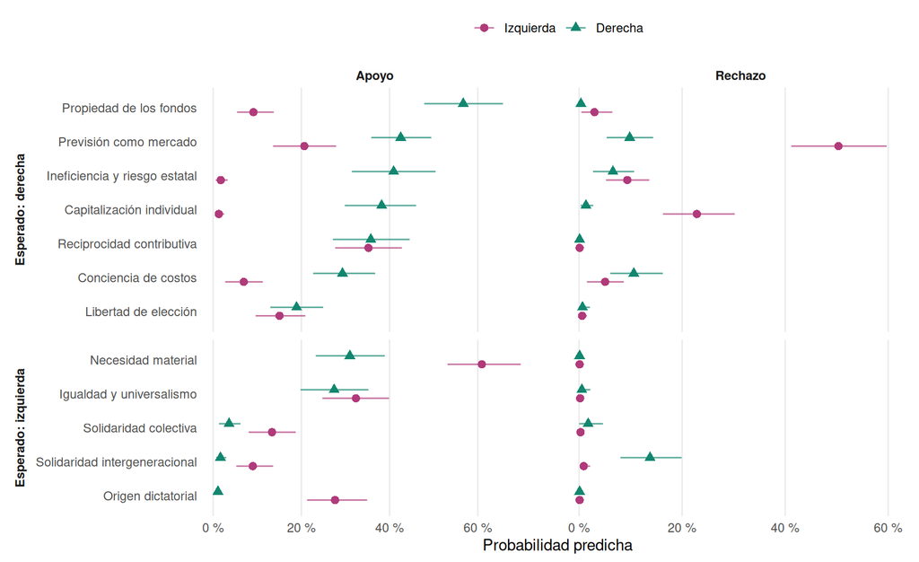

Figura 1: Probabilidad predicha de que una intervención apoye y rechace cada concepto, por bloque político, Ley 21.735

```r
concept_order <- predictions_h1 |>
  filter(postura == "Apoyo", bloque == "derecha") |>
  arrange(estimate) |>
  pull(concepto)
plot_h1 <- predictions_h1 |>
  filter(bloque != "centro") |>
  mutate(bloque = factor(str_to_title(bloque), levels = names(BLOC_COLORS)),
         concepto = factor(concepto, levels = concept_order))
fig_h1 <- ggplot(plot_h1, aes(x = estimate, y = concepto)) +
  geom_errorbar(aes(xmin = conf.low, xmax = conf.high, color = bloque),
                orientation = "y", width = 0, linewidth = 0.5, alpha = 0.7,
                position = position_dodge(width = 0.5)) +
  geom_point(aes(color = bloque, shape = bloque), size = 2.4,
             position = position_dodge(width = 0.5)) +
  facet_grid(esperado ~ postura, scales = "free", space = "free_y",
             switch = "y") +
  # El margen bajo cero evita que se corten los puntos con probabilidad cercana a 0.
  scale_x_continuous(labels = \(x) paste0(round(100 * x), " %"),
                     expand = expansion(mult = c(0.03, 0.08))) +
  expand_limits(x = 0) +
  scale_color_manual(values = BLOC_COLORS) +
  scale_shape_manual(values = c(Izquierda = 16, Derecha = 17)) +
  labs(x = "Probabilidad predicha", y = NULL, color = NULL, shape = NULL) +
  theme(legend.position = "top",
        strip.placement = "outside",
        strip.text.y.left = element_text(angle = 90, face = "bold"),
        strip.text.x = element_text(face = "bold"),
        panel.spacing.x = unit(1.2, "lines"))
print(fig_h1)
ggsave(file.path(FIGURE_DIR, "figura5_h1_probabilidades.png"), fig_h1,
       width = 9, height = 5.5, dpi = 300, bg = "white")
```

## Diferencias entre derecha e izquierda

**Código**

```r
contrasts_h1 |>
  mutate(concepto = factor(concepto, levels = rev(concept_order))) |>
  arrange(postura, esperado, concepto) |>
  transmute(postura, esperado, concepto,
            diferencia = 100 * estimate, ic_inf = 100 * conf.low,
            ic_sup = 100 * conf.high) |>
  knitr::kable(digits = 1, col.names = c("Postura", "Grupo", "Concepto",
                                         "Derecha − izquierda (pp)",
                                         "IC inf.", "IC sup."))
```

| Postura | Grupo | Concepto | Derecha − izquierda (pp) | IC inf. | IC sup. |
| --- | --- | --- | --- | --- | --- |
| Apoyo | Esperado: derecha | Propiedad de los fondos | 47.6 | 37.8 | 57.6 |
| Apoyo | Esperado: derecha | Previsión como mercado | 21.9 | 13.6 | 30.6 |
| Apoyo | Esperado: derecha | Ineficiencia y riesgo estatal | 39.2 | 29.7 | 48.9 |
| Apoyo | Esperado: derecha | Capitalización individual | 36.9 | 28.5 | 44.9 |
| Apoyo | Esperado: derecha | Reciprocidad contributiva | 0.5 | -10.8 | 12.5 |
| Apoyo | Esperado: derecha | Conciencia de costos | 22.4 | 15.2 | 30.1 |
| Apoyo | Esperado: derecha | Libertad de elección | 3.9 | -4.0 | 11.6 |
| Apoyo | Esperado: izquierda | Necesidad material | -29.9 | -41.6 | -19.2 |
| Apoyo | Esperado: izquierda | Igualdad y universalismo | -4.9 | -14.2 | 4.6 |
| Apoyo | Esperado: izquierda | Solidaridad colectiva | -9.7 | -16.0 | -3.9 |
| Apoyo | Esperado: izquierda | Solidaridad intergeneracional | -7.3 | -12.1 | -3.5 |
| Apoyo | Esperado: izquierda | Origen dictatorial | -26.5 | -34.0 | -20.3 |
| Rechazo | Esperado: derecha | Propiedad de los fondos | -2.6 | -6.2 | -0.2 |
| Rechazo | Esperado: derecha | Previsión como mercado | -40.5 | -51.4 | -30.5 |
| Rechazo | Esperado: derecha | Ineficiencia y riesgo estatal | -2.8 | -8.4 | 2.8 |
| Rechazo | Esperado: derecha | Capitalización individual | -21.5 | -29.6 | -15.1 |
| Rechazo | Esperado: derecha | Reciprocidad contributiva | 0.0 | 0.0 | 0.0 |
| Rechazo | Esperado: derecha | Conciencia de costos | 5.6 | 0.1 | 12.0 |
| Rechazo | Esperado: derecha | Libertad de elección | 0.1 | -1.0 | 1.7 |
| Rechazo | Esperado: izquierda | Necesidad material | 0.0 | 0.0 | 0.0 |
| Rechazo | Esperado: izquierda | Igualdad y universalismo | 0.3 | 0.0 | 2.0 |
| Rechazo | Esperado: izquierda | Solidaridad colectiva | 1.5 | 0.0 | 4.4 |
| Rechazo | Esperado: izquierda | Solidaridad intergeneracional | 12.9 | 7.2 | 19.3 |
| Rechazo | Esperado: izquierda | Origen dictatorial | 0.0 | 0.0 | 0.0 |

### Apoyo

En cinco de los siete conceptos esperados en la derecha, la diferencia va en la dirección de H1 y es amplia: propiedad de los fondos (+48 pp; IC 95 % [38; 58]), ineficiencia y riesgo estatal (+39 pp; IC 95 % [30; 49]), capitalización individual (+37 pp; IC 95 % [29; 45]), conciencia de costos (+22 pp; IC 95 % [15; 30]) y previsión como mercado (+22 pp; IC 95 % [14; 31]). La capitalización individual y la ineficiencia estatal casi no tienen apoyo de izquierda (1 % y 2 %). Las excepciones son la reciprocidad contributiva (+1 pp; IC 95 % [−11; 12]) y la libertad de elección (+4 pp; IC 95 % [−4; 12]), que ambos bloques apoyan en proporciones similares.

Entre los conceptos esperados en la izquierda, la necesidad material (−30 pp; IC 95 % [−42; −19]) y el origen dictatorial (−27 pp; IC 95 % [−34; −20]) se ajustan a H1, y las dos solidaridades también, con diferencias pequeñas porque son poco frecuentes en ambos bloques (intergeneracional: −7 pp; IC 95 % [−12; −4]; colectiva: −10 pp; IC 95 % [−16; −4]). La igualdad y el universalismo no distingue a los bloques (−5 pp; IC 95 % [−14; 5]).

Que la izquierda apoye la reciprocidad contributiva y la libertad de elección como la derecha, y la propiedad de los fondos en 9 % de sus intervenciones, es lo que H1 anticipó como evidencia de estructuración: son premisas del polo de preservación reconocidas fuera de él. El patrón es asimétrico: la derecha apoya la necesidad y la igualdad con frecuencia, pero casi nunca el origen dictatorial.

### Rechazo

El rechazo se concentra en pocos conceptos. La izquierda rechaza más que la derecha la previsión como mercado (−41 pp; IC 95 % [−51; −31]) y la capitalización individual (−22 pp; IC 95 % [−30; −15]), y la derecha rechaza más la solidaridad intergeneracional (+13 pp; IC 95 % [7; 19]), como predice H1. La propiedad de los fondos tiene un rechazo de izquierda escaso pero sin contraparte en la derecha (−3 pp; IC 95 % [−6; −0]). La ineficiencia y riesgo estatal se rechaza en proporciones similares en ambos bloques (−3 pp; IC 95 % [−8; 3]), y la conciencia de costos se rechaza más en la derecha, en sentido contrario a H1 (+6 pp; IC 95 % [0; 12]). Esos rechazos de derecha afirman que hay recursos para subir la PGU (Cámara, 2024) o que el acuerdo resguarda la sostenibilidad fiscal (Senado, 2025). En la ineficiencia estatal, tras la adjudicación de postura, la derecha conserva rechazos genuinos de parlamentarios que defienden la autonomía del fondo creado por el acuerdo.

La necesidad material, la reciprocidad contributiva y el origen dictatorial no tienen rechazos, y la igualdad, la libertad de elección y la solidaridad colectiva casi ninguno. En esos conceptos la parte de H1 sobre el rechazo no puede contrastarse: no hay variación entre bloques que comparar, y sus intervalos quedan pegados a cero por construcción.

## Tabla para el anexo

La tabla presenta las probabilidades predichas y las diferencias entre bloques por concepto, que es donde está el contraste de H1. Los coeficientes no se reportan: con efectos aleatorios e interacciones no son directamente interpretables, y la especificación está en el Anexo 4. Se exporta a Word con formato APA 7.

**Código**

```r
dec <- function(x, digits = 1) formatC(round(x, digits) + 0, format = "f", digits = digits, decimal.mark = ",")
ic_txt <- function(est, low, high, digits = 1) {
  paste0(dec(est, digits), " [", dec(low, digits), "; ", dec(high, digits), "]") |>
    str_replace_all("-", "−")
}
panel <- predictions_h1 |>
  filter(bloque != "centro") |>
  transmute(postura, concepto, esperado, bloque,
            valor = ic_txt(100 * estimate, 100 * conf.low, 100 * conf.high)) |>
  # En la tabla, Δ = izquierda − derecha, como en H3: se invierte el signo del
  # contraste (derecha − izquierda) y se intercambian los límites del intervalo.
  bind_rows(contrasts_h1 |>
              transmute(postura, concepto, esperado, bloque = "diferencia",
                        valor = ic_txt(-100 * estimate, -100 * conf.high, -100 * conf.low))) |>
  pivot_wider(names_from = c(postura, bloque), values_from = valor) |>
  arrange(esperado, desc(match(concepto, concept_order)))
section <- \(label) tibble(concepto = label)
tabla_h1 <- bind_rows(
  section("Conceptos esperados en la derecha"),
  filter(panel, esperado == "Esperado: derecha"),
  section("Conceptos esperados en la izquierda"),
  filter(panel, esperado == "Esperado: izquierda")) |>
  select(concepto, Apoyo_izquierda, Apoyo_derecha, Apoyo_diferencia,
         Rechazo_izquierda, Rechazo_derecha, Rechazo_diferencia) |>
  mutate(across(everything(), \(x) coalesce(x, "")))
export_apa7_word_table(
  tabla_h1, file.path(TABLE_DIR, "anexo_h1.docx"),
  "Probabilidad predicha de apoyo y rechazo de los conceptos de H1 por bloque político, Ley N.º 21.735",
  note = paste0(
    "Probabilidad predicha (%) de que una intervención sustantiva apoye o rechace cada ",
    "concepto, a partir de dos modelos logísticos multinivel (apoyo y rechazo), e intervalos ",
    "de confianza del 95 % entre corchetes, obtenidos con 1.000 remuestreos de actores dentro ",
    "de cada bloque. Δ corresponde a izquierda menos derecha, en puntos porcentuales. ",
    format(nobs(m_apoyo), big.mark = "."), " observaciones (intervención × concepto) de ",
    nrow(model_interventions), " intervenciones y ", ngrps(m_apoyo)[["speaker_id"]],
    " actores. La especificación se presenta en el Anexo 4."),
  table_number = 5L, landscape = TRUE, body_font_size = 10,
  header_labels = c("Concepto", rep(c("Izquierda", "Derecha", "Δ (pp)"), 2)),
  header_groups = c(" " = 1, "Apoyo" = 3, "Rechazo" = 3),
  section_rows = which(tabla_h1$Apoyo_izquierda == ""))
```

| Concepto | Apoyo: izquierda | Apoyo: derecha | Apoyo: Δ | Rechazo: izquierda | Rechazo: derecha | Rechazo: Δ |
| --- | --- | --- | --- | --- | --- | --- |
| Conceptos esperados en la derecha |  |  |  |  |  |  |
| Propiedad de los fondos | 9,1 [5,4; 13,7] | 56,7 [47,8; 65,7] | −47,6 [−57,6; −37,8] | 3,0 [0,4; 6,5] | 0,4 [0,1; 0,4] | 2,6 [0,2; 6,2] |
| Previsión como mercado | 20,7 [13,6; 27,9] | 42,5 [35,9; 49,5] | −21,9 [−30,6; −13,6] | 50,3 [41,2; 59,7] | 9,8 [5,4; 14,4] | 40,5 [30,5; 51,4] |
| Ineficiencia y riesgo estatal | 1,7 [0,6; 3,3] | 40,9 [31,4; 50,4] | −39,2 [−48,9; −29,7] | 9,4 [5,2; 13,6] | 6,6 [2,7; 10,7] | 2,8 [−2,8; 8,4] |
| Capitalización individual | 1,3 [0,6; 2,5] | 38,2 [29,8; 46,0] | −36,9 [−44,9; −28,5] | 22,9 [16,3; 30,2] | 1,3 [0,3; 2,8] | 21,5 [15,1; 29,6] |
| Reciprocidad contributiva | 35,2 [27,7; 42,8] | 35,7 [27,1; 44,6] | −0,5 [−12,5; 10,8] | 0,1 [0,1; 0,1] | 0,1 [0,0; 0,1] | 0,0 [0,0; 0,0] |
| Conciencia de costos | 6,9 [2,7; 11,3] | 29,3 [22,7; 36,7] | −22,4 [−30,1; −15,2] | 5,1 [1,5; 8,7] | 10,6 [6,1; 16,3] | −5,6 [−12,0; −0,1] |
| Libertad de elección | 15,0 [9,6; 20,9] | 18,9 [13,0; 24,9] | −3,9 [−11,6; 4,0] | 0,6 [0,1; 1,6] | 0,7 [0,0; 2,1] | −0,1 [−1,7; 1,0] |
| Conceptos esperados en la izquierda |  |  |  |  |  |  |
| Necesidad material | 60,9 [53,1; 69,7] | 31,0 [23,3; 38,9] | 29,9 [19,2; 41,6] | 0,1 [0,1; 0,1] | 0,1 [0,0; 0,1] | 0,0 [0,0; 0,0] |
| Igualdad y universalismo | 32,4 [24,8; 39,9] | 27,4 [19,8; 35,2] | 4,9 [−4,6; 14,2] | 0,2 [0,1; 0,3] | 0,5 [0,0; 2,2] | −0,3 [−2,0; 0,0] |
| Solidaridad colectiva | 13,3 [8,0; 18,7] | 3,6 [1,3; 6,2] | 9,7 [3,9; 16,0] | 0,3 [0,1; 0,3] | 1,8 [0,0; 4,6] | −1,5 [−4,4; 0,0] |
| Solidaridad intergeneracional | 9,0 [5,2; 13,6] | 1,7 [0,7; 3,0] | 7,3 [3,5; 12,1] | 0,9 [0,2; 2,1] | 13,8 [8,0; 19,9] | −12,9 [−19,3; −7,2] |
| Origen dictatorial | 27,6 [21,3; 34,9] | 1,1 [0,7; 1,3] | 26,5 [20,3; 34,0] | 0,1 [0,1; 0,1] | 0,1 [0,0; 0,1] | 0,0 [0,0; 0,0] |